# EDX Capstone - Cloud detection

Alexandre Bort

15 juin 2019

**About me**

Welcome to my report. I’m Alexandre Bort, a french student from ISIMA engineering school. I’m currently attending an internship at the James Hutton Institute (Scotland). This final EDX project is a great opportunity to apply the content of EDX lessons on my real data. Hope you will enjoy reading it!

## Plan of the study

```
I. Introduction
II. Methods - Analysis
    1. Dataset
    2. Pre-processing
        a. Remove worthless columns
        b. Transform `cloud` column
        c. Remove invalid pixels
        d. Distribution - correlation
    3. Models
III. Results
    1. Logistic model
    2. Decision tree
    3. Random Forest
IV. Conclusion
```

# I. Introduction

The last decades, satellite missions has increased with the development of new technologies. The data gathered by the different missions has grown very fast. Today, it’s quite easy to access all this data. Main providers as *ESA* or *NASA* provides public satellite dataset.

Those public dataset bank are provided after several pre-process such as atmospheric, geometric and material corrections, standardization, metadata… However, one really challenging task is remaining: **cloud detection**. More than fifty percent of the earth is covered by clouds. And unfortunately, clouds are between Earth and satellites. This particularly delicate task conditions all the following work.

In my personal work, I have built thirteen different models detecting clouds. In order to have a stronger model, I have decided to build a model based on all those methods. We can think this result model as a **voting system**. The aim of this report is to build this robust model. Those final model should be able to answer if a pixel is a cloud or not. The dataset used is a personal dataset built with Google Earth Engine. If you’re interested in how I build it, pop up me on LinkedIn.

To build this result model, we will study three approaches as seen in EDX class: a **logistic regression model**, a **decision tree model** and a **random forest model**. Then we will compare the **accuracy** of each of those 3 models with our previous methods. Also, I tried the *KNN* model. However, because we are dealing with binary data, the model fails. Indeed, too many points are at equal distance. Moreover, because we are predicting categorical binary output, a **linear model isn’t appropriate**.

# II. Methods - Analysis

## II.1. Dataset

The dataset is a personal dataset showing the results of 13 methods on cloud detection. Each row is the results of the different methods on one pixel. One pixel is defined by a *longitude* and a *latitude*. Each pixel belongs to one *image*. One image is define by this *Google Earth ID*.

```r
head(data_init)
```

```
##   cloud                                             image_id latitude
## 1  True COPERNICUS/S2/20151203T105422_20151203T105811_T30SXH 38.06571
## 2 False COPERNICUS/S2/20151203T105422_20151203T105811_T30SXH 38.34994
## 3 False COPERNICUS/S2/20151203T105422_20151203T105811_T30SXH 37.99421
## 4 False COPERNICUS/S2/20151203T105422_20151203T105811_T30SXH 38.72582
## 5 False COPERNICUS/S2/20151203T105422_20151203T105811_T30SXH 38.02524
## 6 False COPERNICUS/S2/20151203T105422_20151203T105811_T30SXH 38.53441
##   longitude method_1 method_2 method_3 method_4 method_5 method_6 method_7
## 1 -0.786016        0        0        0        0        0        0        1
## 2 -1.563068        0        0        0        0        0        0        1
## 3 -1.775253        0        0        0        0        0        0        1
## 4 -0.892539        0        0        0        0        0        0        1
## 5 -0.878142        0        0        0        0        0        0        1
## 6 -1.416455        0        0        0        0        0        0        1
##   method_8 method_9 method_10 method_11 method_12 method_13
## 1        0        1         0         0         0         0
## 2        0        1         0         0         0         0
## 3        0        1         0         0         0         0
## 4        0        1         0         0         0         0
## 5        0        1         0         0         0         0
## 6        0        1         0         0         0         0
```

The images come from all over the world as shows the folling map:

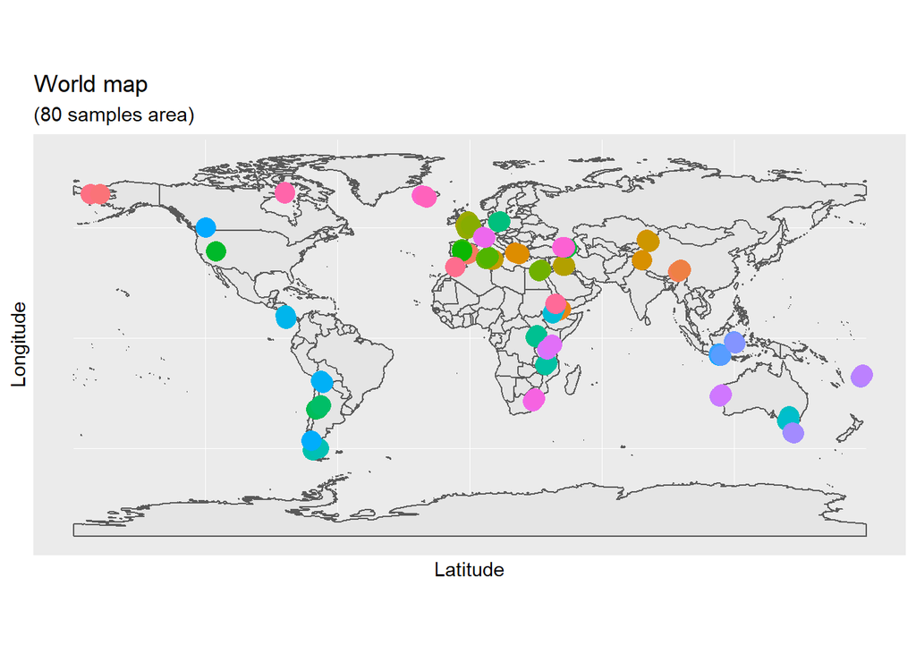

The pixels from one image covers more or less the image.

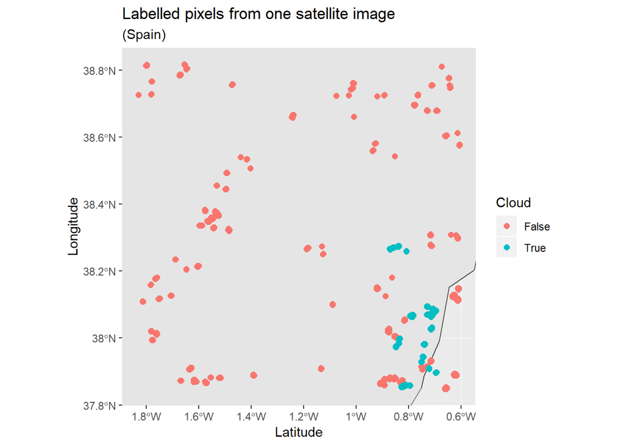

The `method_i` columns provide the result of one method. To make more sens, let see on a real whole image what is the results of the methods. On the left we have our image analyzed, on the right what we consider as a cloud.

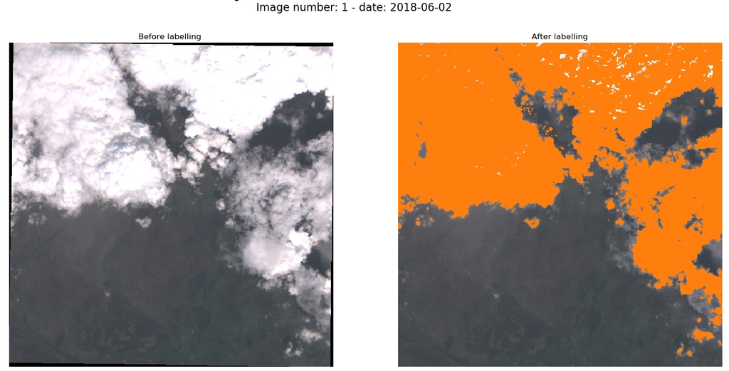

Now that we start knowing more about our dataset, we can jump to the next step: pre-processing !

## II.2. Pre-processing

### a. Remove worthless columns

Immediately, we see worthless columns for our model : `image_id`, `latitude` and `longitude`. We only focus on our methods. The following code remove them:

```r
cols_to_remove <- c("image_id", "latitude", "longitude" )
data <- data[, ! names(data) %in% cols_to_remove, drop = F]
```

### b. Transform `cloud` column

We can also see that the first column is character column having `True` or `False` values. It’s `Python` boolean, not `R` boolean. So we need to transform them as `R` values:

```r
data <- within(data, cloud <- factor(cloud, labels = c(0, 1)))
```

### c. Remove invalid pixels

Now, let see the different output of our methods. Because my methods sometimes fail, a method can return:

- -1 if the method fails
- 0 if the pixel isn’t a cloud
- 1 if the pixel is a cloud So we need to find the pixels (rows) having at least one `-1`. Let see if some methods have failed:

```r
apply(data[, feature_col_names], 2, unique)
```

```
## $method_1
## [1]  0  1 -1
##
## $method_2
## [1]  0  1 -1
##
## $method_3
## [1]  0  1 -1
##
## $method_4
## [1]  0  1 -1
##
## $method_5
## [1]  0  1 -1
##
## $method_6
## [1]  0  1 -1
##
## $method_7
## [1]  1  0 -1
##
## $method_8
## [1]  0  1 -1
##
## $method_9
## [1]  1  0 -1
##
## $method_10
## [1]  0  1 -1
##
## $method_11
## [1] 0 1
##
## $method_12
## [1] 0 1
##
## $method_13
## [1] 0 1
```

Methods 1 to 10 sometimes fail. How many times do they fail:

```r
boolean_vector <- apply(data, 1, function(r) any(r %in% c(-1)))
paste("Number of invalid rows: ", sum(boolean_vector))
```

```
## [1] "Number of invalid rows:  3036"
```

```r
paste("Number of invalid images: ", length(unique(data[boolean_vector,]$image_id)))
```

```
## [1] "Number of invalid images:  0"
```

### d. Distribution - correlation

Remove those pixels:

```r
data <- data[!boolean_vector,]
```

Now that we only have valid data, let see the distribution of each method:

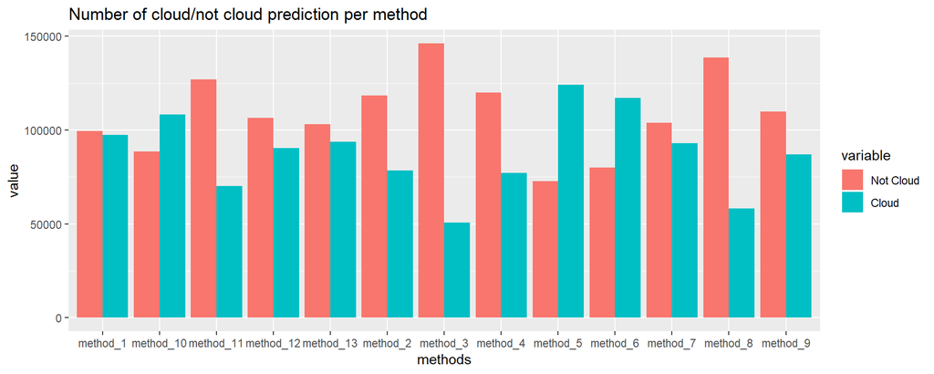

We can also have a look at the **correlation** of our dataset. Contrary to usual cases, ideally, we want a full correlation if all methods are perfect. The following show it is not the case (and we can continue our study, ouf !):

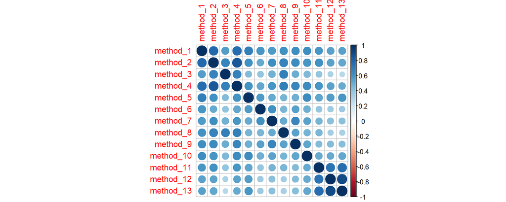

```r
corrplot(cor(data[,2:14]), method="circle")
```

Finally, what our data looks like at the end of the pre-processing step:

```r
dim(data)
```

```
## [1] 196964     14
```

```r
head(data)
```

```
##   cloud method_1 method_2 method_3 method_4 method_5 method_6 method_7
## 1     1        0        0        0        0        0        0        1
## 2     0        0        0        0        0        0        0        1
## 3     0        0        0        0        0        0        0        1
## 4     0        0        0        0        0        0        0        1
## 5     0        0        0        0        0        0        0        1
## 6     0        0        0        0        0        0        0        1
##   method_8 method_9 method_10 method_11 method_12 method_13
## 1        0        1         0         0         0         0
## 2        0        1         0         0         0         0
## 3        0        1         0         0         0         0
## 4        0        1         0         0         0         0
## 5        0        1         0         0         0         0
## 6        0        1         0         0         0         0
```

The next step is to build our training - test dataset. Refer to the `R` code for the detail, nothing new.

## II.3. Models

The first model I will build is a **logistic model**. We want to predict the `cloud` from the methods columns. Because our output is a binary, a linear model isn’t appropriate. The following image clearly show the difference between those two approaches [(source)](https://www.datacamp.com/community/tutorials/logistic-regression-R):

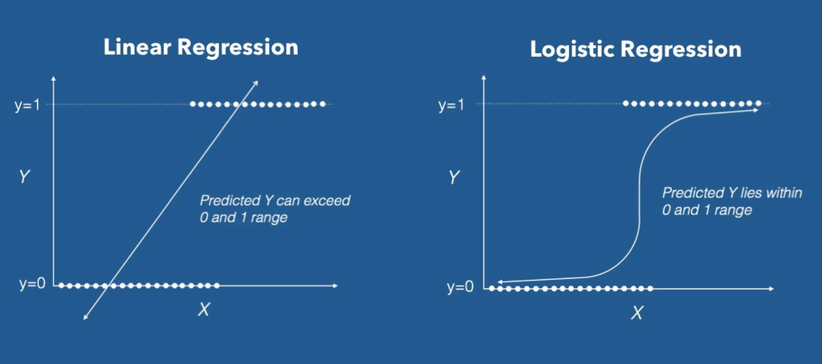

Linear vs Logistic Model

To build this model, I will use the `glm` function from [stats package](https://www.rdocumentation.org/packages/stats/versions/3.6.0/topics/glm).

Then I will build a **decision tree** and a **random forest model**. We will try to reduce the overfitting of our decision tree by creating a “prune” tree and compare the results.

I have also tried to build a *knn* model. However, because our features are really close the ones to the others, the model fails. Too many are at the same distance when come the time to group them.

For the 3 models, we will use the following formula:

```r
predictor_formula <- paste("cloud ~", paste(feature_col_names, collapse = " + "))
predictor_formula
```

```
## [1] "cloud ~ method_1 + method_2 + method_3 + method_4 + method_5 + method_6 + method_7 + method_8 + method_9 + method_10 + method_11 + method_12 + method_13"
```

# III. Results

## III.1. Logistic model

I use the `glm` to build the model and the `predict` function evaluate the model on the `test_set`. In this case, I define the output of the `predict` function as a probability and them determine the class with threshold defined at `0.5`.

```
# Train the model using the training sets
model_glm.fit <- glm(predictor_formula, data = train_set, family = binomial)
# Test the model on test_set
model_glm.probs <- predict(model_glm.fit,
                     newdata = test_set,
                     type = "response")
# Convert the proba response with 0.5 threshold
model_glm.pred <- as.factor(ifelse(model_glm.probs > 0.5, 1, 0))

# Results
conf_mat_glm <- confusionMatrix(model_glm.pred, as.factor(test_set$cloud))
Results@logistic_model <- conf_mat_glm$overall['Accuracy']
```

```r
paste("Accuracy logistic model: ", Results@logistic_model)
```

```
## [1] "Accuracy logistic model:  0.954103520930115"
```

## III.2. Decision tree

To build the decision tree, I use the `rpart` function from the `rpart` package. The output tree is quite a big tree (depth = 13):

```
model_tree <- rpart(predictor_formula, data=train_set, method="class", cp = 0.0001)
# Evaluate model
preds <- predict(object = model_tree, newdata = test_set, type = c("class"))
conf_mat <- confusionMatrix(preds, test_set$cloud)
Results@decision_tree <- conf_mat$overall['Accuracy']
```

```r
paste("Accuracy: ", Results@decision_tree)
```

```
## [1] "Accuracy:  0.96537455893179"
```

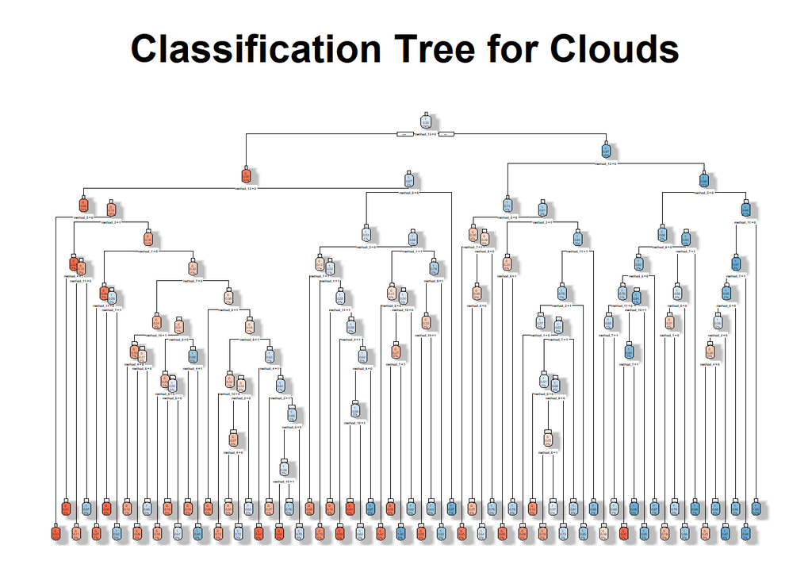

Then, in order to **avoid overfitting**, it is suggested to build a **prune tree**.

```
# prune the tree
prune_tree<- prune(model_tree, cp=model_tree$cptable[which.min(model_tree$cptable[,"xerror"]),"CP"])

# Evaluate model
preds <- predict(object = prune_tree, newdata = test_set, type = c("class"))
conf_mat <- confusionMatrix(preds, test_set$cloud)
Results@prune_tree <- conf_mat$overall['Accuracy']
```

```r
paste("Accuracy: ", Results@prune_tree)
```

```
## [1] "Accuracy:  0.96509532150382"
```

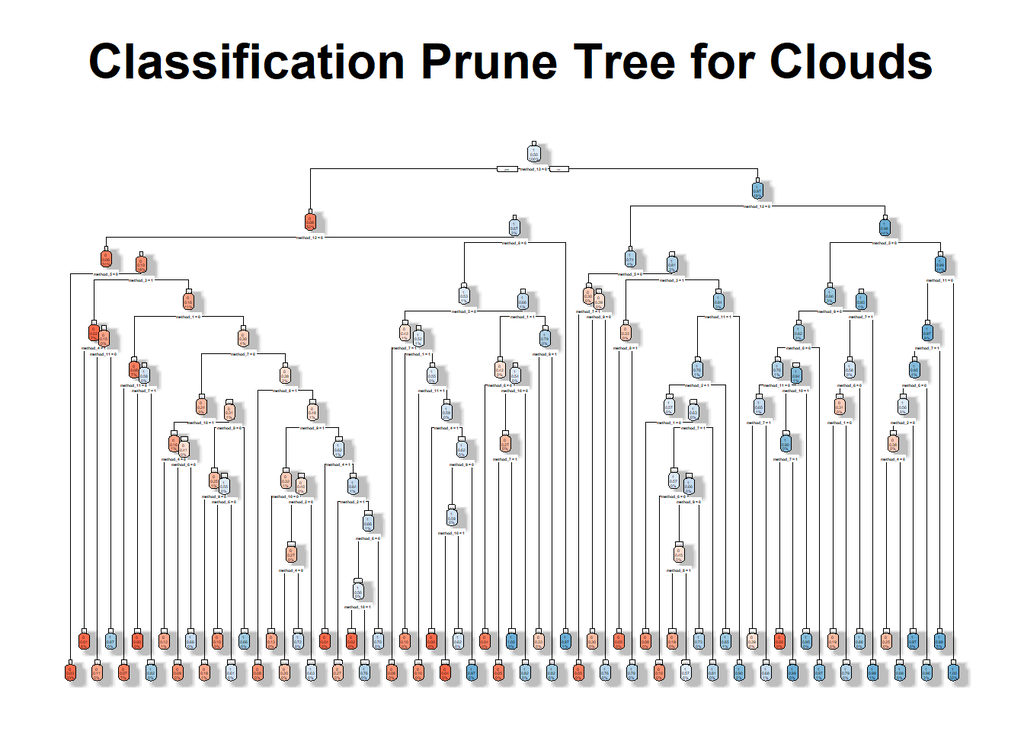

However, the two trees are the same. The accuracy is also the same. So we will just keep the decision tree in the next of the report.

## III.3. Random Forest

The last model built is a random forest model. To do this, I use the `randomForest` method from the `randomForest` package.

```
# Build model
model_randomForest <- randomForest(x = train_x, y = train_set$cloud)
# Evaluate model
preds <- predict(object = model_randomForest, newdata = test_set, type = c("class"))

conf_mat <- confusionMatrix(preds, test_set$cloud)
Results@random_forest <- conf_mat$overall['Accuracy']
```

```r
paste("Accuracy random forest: ", Results@random_forest)
```

```
## [1] "Accuracy random forest:  0.964993780620922"
```

## Summary

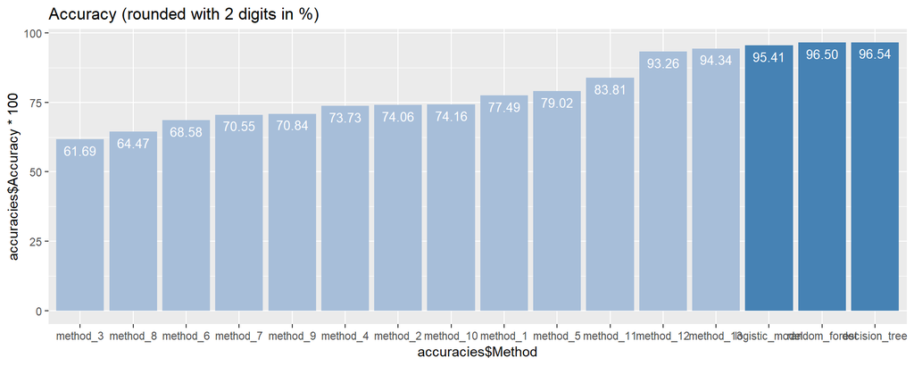

# IV. Conclusion

The result are pretty good. Compare to the best methods (method_13), we have been able to improve the accuracy by 2%. Because we are in the last percentage, this gain is very good !

This edx capstone has been a great opportunity to apply the content of the course. We apply much more by practicing!

I hope this report hasn’t been so boring, if it was, I apologize for! Thank you the edx team. Thank you for reading !

If you have been interested by the content of my project and want to know more, send me a message on LinkedIn !